# Common Extensions

```r
# if needed
library(tidyverse)
library(lme4)
load('data/gpa.RData')

# if you want to run all the code, you'll need to install the following
# install.packages(c('sjstats', 'merTools', 'broom'))
```

## Additional Grouping Structure

### Crossed random effects

Load the pupils data. We’ll look at achievement scores for students. The sources of dependency are due to students having gone to the same primary or secondary schools. However, in this example, going to a primary school doesn’t necessarily mean you’ll go to a specific secondary school. Note also that there are no repeated measures, we see each student only once.

```r
load('data/pupils.RData')

pupils
```

| PUPIL | primary_school_id | secondary_school_id | achievement | sex | ses | primary_denominational | secondary_denominational |
| --- | --- | --- | --- | --- | --- | --- | --- |
| 1 | 1 | 2 | 6.6 | female | highest | no | no |
| 2 | 1 | 1 | 5.7 | male | lowest | no | yes |
| 3 | 1 | 17 | 4.5 | male | 2 | no | no |
| 4 | 1 | 3 | 4.4 | male | 2 | no | no |
| 5 | 1 | 4 | 5.8 | male | 3 | no | yes |
| 6 | 1 | 4 | 5.0 | female | 4 | no | yes |
| 7 | 1 | 4 | 4.9 | male | 3 | no | yes |
| 8 | 1 | 17 | 5.3 | female | 2 | no | no |
| 9 | 1 | 14 | 9.0 | male | highest | no | yes |
| 10 | 1 | 22 | 5.4 | male | lowest | no | no |

[output cut: 990 more lines]

#### Primary and Secondary School Random Effects

We’ll do a model with random effects for both primary and secondary school. As such, we’ll get variance components for each as well.

```r
pupils_crossed = lmer(achievement ~ sex + ses
                      + (1|primary_school_id) + (1|secondary_school_id),
                      data = pupils)

summary(pupils_crossed, correlation=F)
```

```
Linear mixed model fit by REML ['lmerMod']
Formula: achievement ~ sex + ses + (1 | primary_school_id) + (1 | secondary_school_id)
   Data: pupils

REML criterion at convergence: 2260.9

Scaled residuals:
    Min      1Q  Median      3Q     Max
-3.1212 -0.6673 -0.0049  0.6596  3.5676

Random effects:
 Groups              Name        Variance Std.Dev.
 primary_school_id   (Intercept) 0.17316  0.4161
 secondary_school_id (Intercept) 0.06602  0.2570
 Residual                        0.47312  0.6878
Number of obs: 1000, groups:  primary_school_id, 50; secondary_school_id, 30

Fixed effects:
            Estimate Std. Error t value
(Intercept)  5.92387    0.12264  48.303
sexfemale    0.26077    0.04562   5.716
ses2         0.13188    0.11750   1.122
ses3         0.09799    0.11010   0.890
ses4         0.29818    0.10459   2.851
ses5         0.35376    0.10066   3.514
seshighest   0.61622    0.11000   5.602
```

In this case, the primary school displays more variance.

```r
VarCorr(pupils_crossed) %>%
  print(comp=c('Var', 'Std'), digits=3)
```

```
 Groups              Name        Variance Std.Dev.
 primary_school_id   (Intercept) 0.173    0.416
 secondary_school_id (Intercept) 0.066    0.257
 Residual                        0.473    0.688
```

```r
sjstats::icc(pupils_crossed) # relative proportion due to each school
```

```
Intraclass Correlation Coefficient for Linear mixed model

Family : gaussian (identity)
Formula: achievement ~ sex + ses + (1 | primary_school_id) + (1 | secondary_school_id)

    ICC (primary_school_id): 0.2431
  ICC (secondary_school_id): 0.0927
```

Note the specific random effects for 50 distinct primary schools vs. 30 distinct secondary schools.

```r
str(ranef(pupils_crossed))
```

```
List of 2
 $ primary_school_id  :'data.frame':    50 obs. of  1 variable:
  ..$ (Intercept): num [1:50] -0.327 0.183 0.52 0.474 0.253 ...
 $ secondary_school_id:'data.frame':    30 obs. of  1 variable:
  ..$ (Intercept): num [1:30] -0.41069 0.08247 -0.00589 -0.06162 0.08481 ...
 - attr(*, "class")= chr "ranef.mer"
```

We can use the `merTools` package to visualize. Install it if you haven’t already. This plot allows to visually see the increased variability due to primary schools relative to secondary.

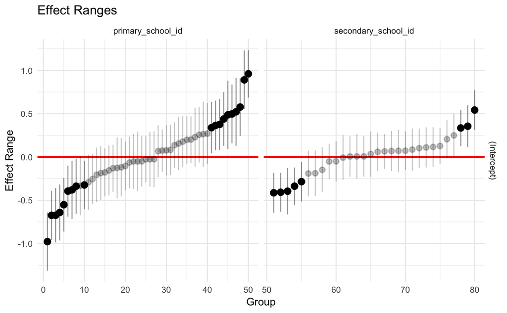

```r
library(merTools)
plotREsim(REsim(pupils_crossed)) +
  theme_minimal()
```

### Hierarchical Structure

Load and inspect the nurses data. Here we are interested in the effect of a training program (`treatment`) on stress levels (on a scale of 1-7) of nurses. In this scenario, nurses are nested within wards, which themselves are nested within hospitals, so we will have random effects pertaining to ward (within hospital) and hospital.

| hospital | ward | wardid | nurse | age | sex | experience | stress | wardtype | hospsize | treatment |
| --- | --- | --- | --- | --- | --- | --- | --- | --- | --- | --- |
| 1 | 1 | 11 | 1 | 36 | Male | 11 | 7 | general care | large | Training |
| 1 | 1 | 11 | 2 | 45 | Male | 20 | 7 | general care | large | Training |
| 1 | 1 | 11 | 3 | 32 | Male | 7 | 7 | general care | large | Training |
| 1 | 1 | 11 | 4 | 57 | Female | 25 | 6 | general care | large | Training |
| 1 | 1 | 11 | 5 | 46 | Female | 22 | 6 | general care | large | Training |
| 1 | 1 | 11 | 6 | 60 | Female | 22 | 6 | general care | large | Training |
| 1 | 1 | 11 | 7 | 23 | Female | 13 | 6 | general care | large | Training |
| 1 | 1 | 11 | 8 | 32 | Female | 13 | 7 | general care | large | Training |
| 1 | 1 | 11 | 9 | 60 | Male | 17 | 7 | general care | large | Training |
| 1 | 2 | 12 | 10 | 45 | Male | 21 | 6 | special care | large | Training |

[output cut: 990 more lines]

There are two different ways to note a nested structure with `lme4`. Either is fine. As before, we have two sources of variability, and with this data it is with ward and hospital.

```r
nurses_hierarchical = lmer(stress ~ age + sex + experience
                           + treatment + wardtype + hospsize
                           + (1|hospital) + (1|hospital:ward),
                           data = nurses)

nurses_hierarchical = lmer(stress ~ age  + sex + experience
                           + treatment + wardtype + hospsize
                           + (1|hospital/ward),
                           data = nurses) # same thing!

summary(nurses_hierarchical, correlation=F)
```

```
Linear mixed model fit by REML ['lmerMod']
Formula: stress ~ age + sex + experience + treatment + wardtype + hospsize +      (1 | hospital/ward)
   Data: nurses

REML criterion at convergence: 1640

Scaled residuals:
     Min       1Q   Median       3Q      Max
-2.62082 -0.69562 -0.00134  0.66513  2.75800

Random effects:
 Groups        Name        Variance Std.Dev.
 ward:hospital (Intercept) 0.3366   0.5801
 hospital      (Intercept) 0.1194   0.3455
 Residual                  0.2174   0.4662
Number of obs: 1000, groups:  ward:hospital, 100; hospital, 25

Fixed effects:
                      Estimate Std. Error t value
(Intercept)           5.379585   0.184686  29.128
age                   0.022114   0.002200  10.053
sexFemale            -0.453184   0.034991 -12.952
experience           -0.061653   0.004475 -13.776
treatmentTraining    -0.699851   0.119767  -5.843
wardtypespecial care  0.050807   0.119767   0.424
hospsizemedium        0.489400   0.201547   2.428
hospsizelarge         0.901527   0.274824   3.280
```

```r
nurses_hierarchical %>%
  broom::tidy('fixed', conf.int=T) %>%
  mutate_if(is.numeric, round, digits = 2)
```

| term | estimate | std.error | statistic | conf.low | conf.high |
| --- | --- | --- | --- | --- | --- |
| (Intercept) | 5.38 | 0.18 | 29.13 | 5.02 | 5.74 |
| age | 0.02 | 0.00 | 10.05 | 0.02 | 0.03 |
| sexFemale | -0.45 | 0.03 | -12.95 | -0.52 | -0.38 |
| experience | -0.06 | 0.00 | -13.78 | -0.07 | -0.05 |
| treatmentTraining | -0.70 | 0.12 | -5.84 | -0.93 | -0.47 |
| wardtypespecial care | 0.05 | 0.12 | 0.42 | -0.18 | 0.29 |
| hospsizemedium | 0.49 | 0.20 | 2.43 | 0.09 | 0.88 |
| hospsizelarge | 0.90 | 0.27 | 3.28 | 0.36 | 1.44 |

As far as the fixed effects go, about the only thing that doesn’t have a statistical effect is ward type.

There appears to be more variability due to ward than that due to hospital.

```r
VarCorr(nurses_hierarchical)
```

```
 Groups        Name        Std.Dev.
 ward:hospital (Intercept) 0.58014
 hospital      (Intercept) 0.34547
 Residual                  0.46624
```

### Crossed vs. Nested

The following shows the difference in the results from treating ward as a nested (within hospital) vs. crossed random effect. What do you notice is different?

```r
nurses_hierarchical1 = lmer(stress ~ age  + sex + experience
                           + treatment + wardtype + hospsize
                           + (1|hospital) + (1|hospital:ward), data = nurses)

nurses_crossed1 = lmer(stress ~ age  + sex + experience
                           + treatment + wardtype + hospsize
                           + (1|hospital) + (1|ward), data = nurses)
```

```
singular fit
```

```r
nurses_crossed2 = lmer(stress ~ age  + sex + experience
                           + treatment + wardtype + hospsize
                           + (1|hospital) + (1|wardid), data = nurses)
```

```r
VarCorr(nurses_hierarchical1)
```

```
 Groups        Name        Std.Dev.
 hospital:ward (Intercept) 0.58014
 hospital      (Intercept) 0.34547
 Residual                  0.46624
```

```r
VarCorr(nurses_crossed1)
```

```
 Groups   Name        Std.Dev.
 hospital (Intercept) 0.44216
 ward     (Intercept) 0.00000
 Residual             0.68071
```

```r
VarCorr(nurses_crossed2)
```

```
 Groups   Name        Std.Dev.
 wardid   (Intercept) 0.58014
 hospital (Intercept) 0.34547
 Residual             0.46624
```

## Residual Structure

### Heterogeneous Variances

```r
library(nlme)
heterovar_res = lme(gpa ~ occasion,
                    data = gpa,
                    random = ~1|student,
                    weights = varIdent(form = ~1|occasion))

summary(heterovar_res)
```

```
Linear mixed-effects model fit by REML
 Data: gpa
```

|  | AIC | BIC | logLik |
| --- | --- | --- | --- |
|  | 274.0536 | 319.8492 | -128.0268 |

```
Random effects:
 Formula: ~1 | student
        (Intercept)  Residual
StdDev:    0.305992 0.3716858

Variance function:
 Structure: Different standard deviations per stratum
 Formula: ~1 | occasion
 Parameter estimates:
        0         1         2         3         4         5
1.0000000 0.8261186 0.6272415 0.4311126 0.3484013 0.4324628
Fixed effects: gpa ~ occasion
```

|  | Value | Std.Error | DF | t-value | p-value |
| --- | --- | --- | --- | --- | --- |
| (Intercept) | 2.5987900 | 0.026249746 | 999 | 99.00248 | 0 |
| occasion | 0.1061401 | 0.004033168 | 999 | 26.31680 | 0 |

```
 Correlation:
         (Intr)
occasion -0.528

Standardized Within-Group Residuals:
        Min          Q1         Med          Q3         Max
-2.74415646 -0.64519742  0.02266271  0.62705166  3.05558475

Number of Observations: 1200
Number of Groups: 200
```

```r
# values are relative to redisual variance and on the standard deviation scale
summary(heterovar_res$modelStruct)
```

```
Random effects:
 Formula: ~1 | student
        (Intercept) Residual
StdDev:   0.8232544        1

Variance function:
 Structure: Different standard deviations per stratum
 Formula: ~1 | occasion
 Parameter estimates:
        0         1         2         3         4         5
1.0000000 0.8261186 0.6272415 0.4311126 0.3484013 0.4324628
```

```r
summary(heterovar_res2) # you can ignore the Corr part in the random effects output
```

```
 Family: gaussian  ( identity )
Formula:          gpa ~ occasion + (1 | student) + ar1(0 + occas | student)
Data: gpa

     AIC      BIC   logLik deviance df.resid
   290.5    321.0   -139.2    278.5     1194

Random effects:

Conditional model:
 Groups    Name                   Variance  Std.Dev.  Corr
 student   (Intercept)            2.441e-10 1.563e-05
 student.1 occasyear 1 semester 1 9.283e-02 3.047e-01 0.84 (ar1)
 Residual                         2.791e-02 1.671e-01
Number of obs: 1200, groups:  student, 200

Dispersion estimate for gaussian family (sigma^2): 0.0279

Conditional model:
            Estimate Std. Error z value Pr(>|z|)
(Intercept) 2.597577   0.023385  111.08   <2e-16 ***
occasion    0.106875   0.005493   19.46   <2e-16 ***
---
Signif. codes:  0 ‘***’ 0.001 ‘**’ 0.01 ‘*’ 0.05 ‘.’ 0.1 ‘ ’ 1
```

```r
vc_glmmtmb = VarCorr(heterovar_res2)
vc_glmmtmb = attr(vc_glmmtmb$cond$student.1, 'stddev')^2 + sigma(heterovar_res2)^2
vc_glmmtmb
```

[output not shown]

### Autocorrelation

```r
corr_res
```

```
Linear mixed-effects model fit by REML
  Data: gpa
  Log-restricted-likelihood: -162.0604
  Fixed: gpa ~ occasion
(Intercept)    occasion
  2.5969002   0.1071433

Random effects:
 Formula: ~1 | student
        (Intercept)  Residual
StdDev:   0.2145887 0.2732718

Correlation Structure: AR(1)
 Formula: ~0 + occasion | student
 Parameter estimate(s):
      Phi
0.4182174
Number of Observations: 1200
Number of Groups: 200
```

## Generalized Linear Mixed Models

Note that `nlme` does not model beyond the gaussian distribution, so we go back to using `lme4` and the `glmer` function. You may notice that it takes the model a second or two even though it is not that complex. GLMM are often hard to estimate, and you will often encounter convergence issues. Scaling the data can help a lot.

```r
load('data/speed_dating.RData')

sd_model = glmer(
  decision ~ sex + samerace + attractive_sc + sincere_sc + intelligent_sc
  + (1|iid),
  data = speed_dating,
  family = binomial
)

summary(sd_model, correlation=F)
```

[output not shown]

## Exercises

### Sociometric data

In the following data, kids are put into different groups and rate each other in terms of how much they would like to share some activity with the others. We have identifying variables for the person doing the rating (sender), the person being rated (receiver), what group they are in, as well as age and sex for both sender and receiver, as well as group size.

To run a mixed model, we will have three sources of structure to consider:

- senders (within group)
- receivers (within group)
- group

First, load the sociometric data.

```r
load('data/sociometric.RData')
```

To run the model, we will proceed with the following modeling steps. For each, make sure you are creating a separate model object for each model run.

- Model 1: No covariates, only sender and receiver random effects. Note that even though we don’t add group yet, still use the nesting approach to specify the effects (e.g. `1|group:receiver`)
- Model 2: No covariates, add group random effect
- Model 3: Add all covariates: `agesend/rec`, `sexsend/rec`, and `grsize` (group size)
- Model 4: In order to examine sex matching effects, add an interaction of the sex variables to the model `sexsend:sexrec`.
- Compare models with AIC, e.g. `AIC(model1)`. A lower value would indicate the model is preferred.

```r
model1 = lmer(rating ~ (1|group:sender) + (1|group:receiver),
             data=sociometric)
summary(model1, correlation=F)

model2 = lmer(rating ~ (1|group:sender) + (1|group:receiver) + (1|group),
             data=sociometric)
summary(model2, correlation=F)

model3 = lmer(rating ~ sexsend + sexrec + agesend + agerec + grsize
              + (1|group:sender) + (1|group:receiver) + (1|group),
             data=sociometric)
summary(model3, correlation=F)

model4 = lmer(rating ~ sexsend*sexrec + agesend + agerec + grsize
              + (1|group:sender) + (1|group:receiver) + (1|group),
             data=sociometric)
summary(model4, correlation=F)

c(AIC(model1), AIC(model2), AIC(model3), AIC(model4))
```

### Patents

Do a Poisson mixed effect model using the `patent` data. Model the number of citations (`ncit`) based on whether there was opposition to the patent (`opposition`) and if it was for the biotechnology/pharmaceutical industry (`biopharm`). Use year as a random effect to account for unspecified economic conditions.

```r
load('data/patents.RData')

model_poisson = glmer(ncit ~ opposition + biopharm + (1 | year),
                      data = patents,
                      family = 'poisson')

summary(model_poisson)
```

Interestingly, one can model overdispersion in a Poisson model by specifying an random intercept for each observation (`subject` in the data). In other words, no clustering or grouped structure is necessary.